# A1

Tatsuya Seamus Corlett

2023-02-14

# Introduction

Prostate cancer is a leading cause of male cancer-related death. One characteristic of prostate cancer is persistent AR (androgen receptor) signaling, where AR is a nuclear steroid hormone receptor which acts as a transcription factor to upregulate multiple genes responsible for cancer growth. p300 and CBP are paralogous, highly conserved proteins that are potent co-activators of AR signaling.

A recent study tested the efficacy of CCS1477, a novel small-molecule inhibitor of the p300/CBP conserved bromodomain, as a potential therapeutic agent for treating lethal prostate cancer (de Bono et al., 2021)[1]. The study uses 22Rv1 (human prostate carcinoma epithelial cell line) where 3 samples are treated with CCS1477, and 3 are controls[[^1]](http://localhost:8787/files/a1_report.html#fn1).

There is another set of 3 samples where the cells are treated with JQ1, a known bromodomain protein inhibitor. These are excluded for this assignment, since it is mentioned that “samples treated with JQ1 or CCS1477 displayed a high degree of separation after PCA, suggesting that these samples have distinct transcriptional alterations after drug treatment”.

Prostate cancer research is of personal interest to me since one of my grandfathers passed away from prostate cancer in 2011. Through this assignment, my goal is to better understand how bioinformatics is used to study novel cancer therapeutics [[^2]](http://localhost:8787/files/a1_report.html#fn2).

# Procedures & Results

## Selecting a Dataset

```r
# required packages
if (!requireNamespace("BiocManager", quietly = TRUE)){
    install.packages("BiocManager")}
if (!requireNamespace("GEOmetadb", quietly = TRUE)){
    BiocManager::install("GEOmetadb")}
library("BiocManager")
library("GEOmetadb")
library("biomaRt")
```

Based on the criteria, the following series was chosen:

- GSE162564 - Targeting p300/CBP axis in lethal prostate cancer

(details are documented in the journal)

```r
gse <- getGEO("GSE162564",GSEMatrix=FALSE)
knitr::kable(data.frame(head(Meta(gse))), format = "html")
```

| contact_address | contact_city | contact_country | contact_department | contact_email | contact_institute |
| --- | --- | --- | --- | --- | --- |
| 1028A BLSB 233 South 10th Street | Philadelphia | USA | Cancer Biology | christopher.mcnair@jefferson.edu | Thomas Jefferson University |

```r
# Get the expression data:
sfiles = getGEOSuppFiles('GSE162564')
fnames = rownames(sfiles)
p300_CBP_exp = read.delim(fnames[1],header=TRUE, check.names = FALSE)

# see what it looks like
knitr::kable(p300_CBP_exp[1:5,1:5], format = "html")
```

| Geneid | Chr | Start | End | Strand |
| --- | --- | --- | --- | --- |
| ENSG00000223972 | 1;1;1;1 | 11869;12595;12975;13221 | 12227;12721;13052;14412 | +;+;+;+ |
| ENSG00000227232 | 1;1;1;1;1;1;1;1;1;1;1;1;1 | 14363;14970;15796;16607;16854;17233;17498;17602;17915;18268;24734;29321;29534 | 14829;15038;15947;16765;17055;17368;17504;17742;18061;18379;24891;29370;29806 | -;-;-;-;-;-;-;-;-;-;-;-;- |
| ENSG00000243485 | 1;1;1 | 29554;30267;30976 | 30039;30667;31109 | +;+;+ |
| ENSG00000237613 | 1;1;1 | 34554;35245;35721 | 35174;35481;36081 | -;-;- |
| ENSG00000268020 | 1;1 | 52473;54830 | 53312;54936 | +;+ |

```r
dim(p300_CBP_exp)
```

```
## [1] 63677    15
```

```r
colnames(p300_CBP_exp)
```

```
##  [1] "Geneid"          "Chr"             "Start"           "End"
##  [5] "Strand"          "Length"          "22Rv1-CCS1477-1" "22Rv1-CCS1477-2"
##  [9] "22Rv1-CCS1477-3" "22Rv1-Control-1" "22Rv1-Control-2" "22Rv1-Control-3"
## [13] "22Rv1-JQ1-1"     "22Rv1-JQ1-2"     "22Rv1-JQ1-3"
```

## Clean the data

**Check for duplicate gene IDs[[^3]](http://localhost:8787/files/a1_report.html#fn3)**

```r
# Do any genes appear more than once?
summarized_gene_counts <- sort(table(p300_CBP_exp$Geneid), decreasing = TRUE)
# check the column
knitr::kable(table(p300_CBP_exp$Geneid)[1:3], format="html")
```

| Var1 | Freq |
| --- | --- |
| ENSG00000000003 | 1 |
| ENSG00000000005 | 1 |
| ENSG00000000419 | 1 |

```r
# show duplicates:
knitr::kable(summarized_gene_counts[which(summarized_gene_counts>1)[1:10]], format="html")
```

| Var1 | Freq |
| --- | --- |
| NA | NA |
| NA | NA |
| NA | NA |
| NA | NA |
| NA | NA |
| NA | NA |
| NA | NA |
| NA | NA |
| NA | NA |
| NA | NA |

```r
# all NA! no duplicate genes in this data
```

**Filter out low counts**

```r
# check the counts: 3 treatment & 3 control
head(p300_CBP_exp[,7:12])
```

```
##   22Rv1-CCS1477-1 22Rv1-CCS1477-2 22Rv1-CCS1477-3 22Rv1-Control-1
## 1               0               3               1               4
## 2              47              67              67              37
## 3               0               0               0               0
## 4               0               0               0               0
## 5               0               0               0               0
## 6               0               0               0               0
##   22Rv1-Control-2 22Rv1-Control-3
## 1               1               0
## 2              38              44
## 3               0               0
## 4               0               0
## 5               0               0
## 6               0               0
```

```r
# translate counts into "counts per million" using the edgeR package function cpm
cpms = edgeR::cpm(p300_CBP_exp[,7:12])
rownames(cpms) <- p300_CBP_exp[,1]

# In edgeR, the standard is to remove features without at least 1 cpm
# in n of the samples, where n = size of the smallest group of replicates
# For this study, n = 3
keep = rowSums(cpms >1) >=3
p300_CBP_exp_filtered = p300_CBP_exp[keep,]
dim(p300_CBP_exp_filtered)
```

```
## [1] 15790    15
```

**Check for outliers**

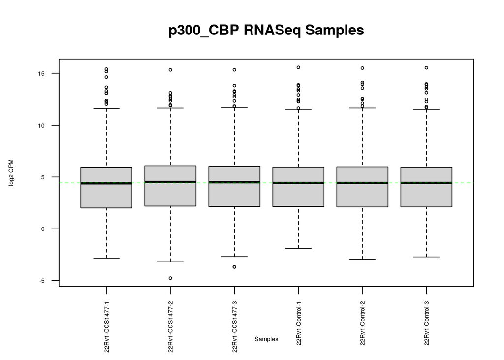

```r
data2plot <- log2(edgeR::cpm(p300_CBP_exp_filtered[,7:12]))
boxplot(data2plot, xlab = "Samples", ylab = "log2 CPM",
las = 2, cex = 0.5, cex.lab = 0.5,
cex.axis = 0.5, main = "p300_CBP RNASeq Samples")

#draw the median on each box plot
abline(h = median(apply(data2plot, 2, median)), col = "green", lwd = 0.6, lty = "dashed")
```

**Create DGE (differential gene expression) list object[[^5]](http://localhost:8787/files/a1_report.html#fn5)**

```r
# need to create "group"s for DGE list
samples <- data.frame(lapply(colnames(p300_CBP_exp)[7:12], FUN=function(x){unlist(strsplit(x, split = "-"))[c(2,3)]}))  # c(2,3) to grab the second and third elements
colnames(samples) <- colnames(p300_CBP_exp)[7:12]
rownames(samples) <- c("cell_type","replicate")
samples <- data.frame(t(samples))  # transpose
samples
```

```
##                 cell_type replicate
## 22Rv1-CCS1477-1   CCS1477         1
## 22Rv1-CCS1477-2   CCS1477         2
## 22Rv1-CCS1477-3   CCS1477         3
## 22Rv1-Control-1   Control         1
## 22Rv1-Control-2   Control         2
## 22Rv1-Control-3   Control         3
```

```r
# now create a DGE list
filtered_data_matrix <- as.matrix(p300_CBP_exp_filtered[,7:12])
rownames(filtered_data_matrix) <- p300_CBP_exp_filtered$Geneid
d = edgeR::DGEList(counts=filtered_data_matrix, group=samples$cell_type)
```

**Dispersion**

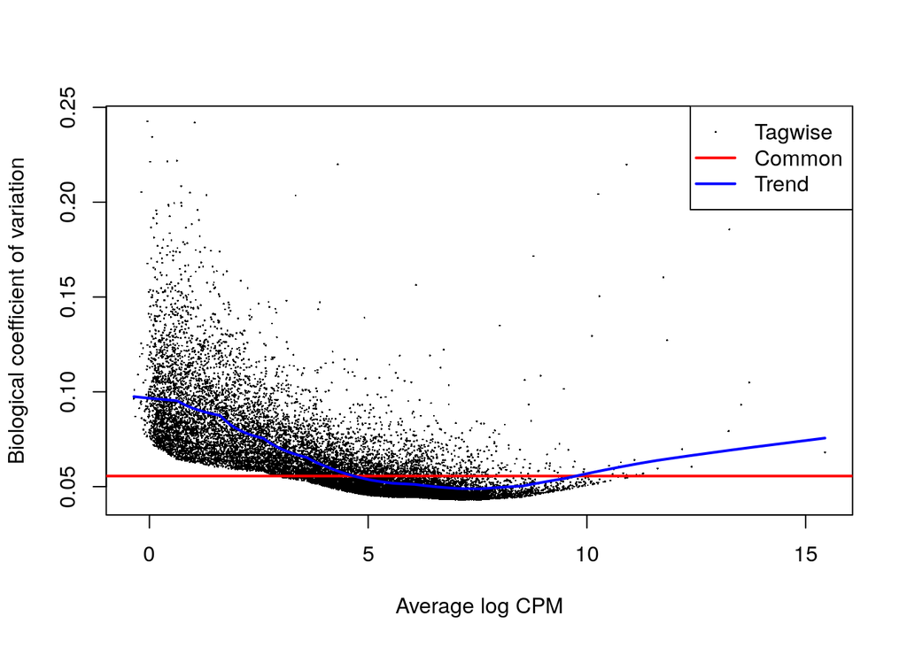

```r
# Checking the dispersion of our data
model_design <- model.matrix(~samples$replicate
                             + samples$cell_type+0)  # define a model first
d <- edgeR::estimateDisp(d, model_design)
edgeR::plotBCV(d,col.tagwise = "black",col.common = "red",)
```

It shows the general trend where low counts have higher dispersion. Here’s an alternative plot that shows the same trend:

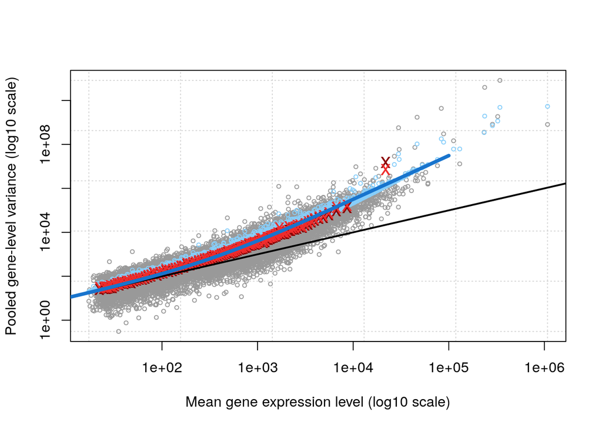

```r
edgeR::plotMeanVar(d, show.raw.vars = TRUE,
            show.tagwise.vars=TRUE,
            NBline=TRUE, show.ave.raw.vars = TRUE,
            show.binned.common.disp.vars = TRUE)
```

## Apply Normalization

First, determine the shape of our data:

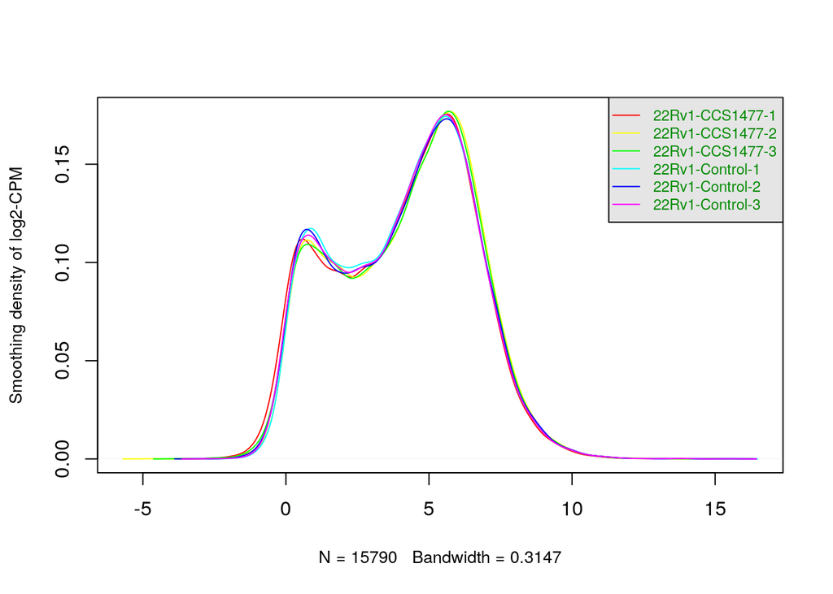

```r
counts_density <- apply(log2(edgeR::cpm(p300_CBP_exp_filtered[,7:12])),
2, density)
#calculate the limits across all the samples
xlim <- 0; ylim <- 0
for (i in 1:length(counts_density)) {
xlim <- range(c(xlim, counts_density[[i]]$x));
ylim <- range(c(ylim, counts_density[[i]]$y))
}
cols <- rainbow(length(counts_density))
ltys <- rep(1, length(counts_density))

#plot the first density plot to initialize the plot
plot(counts_density[[1]], xlim=xlim, ylim=ylim, type="n",
ylab="Smoothing density of log2-CPM",
main="", cex.lab = 0.85)

#plot each line
for (i in 1:length(counts_density)) {lines(counts_density[[i]], col=cols[i], lty=ltys[i])}
#create legend
legend("topright", colnames(data2plot),
col=cols, lty=ltys, cex=0.75,
border ="blue", text.col = "green4",
merge = TRUE, bg = "gray90")
```

Although this is not a perfect normal distribution, for our purposes, TMM (Trimmed Mean of M-values) should suffice:

```r
# perform normalization
d = edgeR::calcNormFactors(d)
d$samples[1:6,]
```

```
##                   group lib.size norm.factors
## 22Rv1-CCS1477-1 CCS1477 21367365    0.9637916
## 22Rv1-CCS1477-2 CCS1477 27170646    1.0673949
## 22Rv1-CCS1477-3 CCS1477 25795429    1.0350887
## 22Rv1-Control-1 Control 22258651    0.9766688
## 22Rv1-Control-2 Control 23239106    0.9863839
## 22Rv1-Control-3 Control 26226634    0.9748120
```

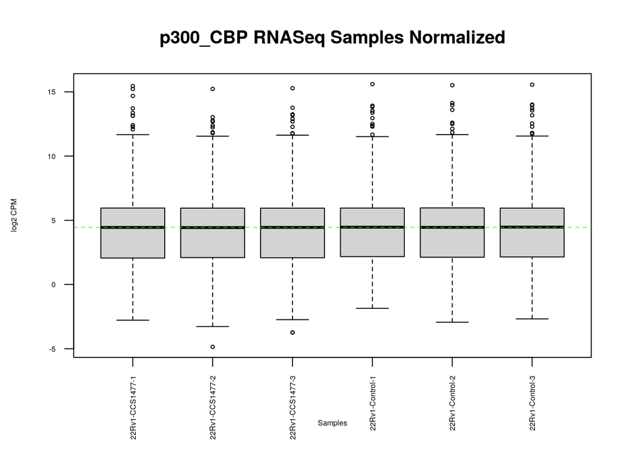

```r
# get the normalized data
normalized_counts <- edgeR::cpm(d)

# see the difference
data2plot <- log2(normalized_counts[,1:6])
boxplot(data2plot, xlab = "Samples", ylab = "log2 CPM",
las = 2, cex = 0.5, cex.lab = 0.5,
cex.axis = 0.5, main = "p300_CBP RNASeq Samples Normalized")
#draw the median on each box plot
abline(h = median(apply(data2plot, 2, median)), col = "green", lwd = 0.6, lty = "dashed")
```

Compared to the pre-normalization plot, the medians are better aligned.

**MDS plot**

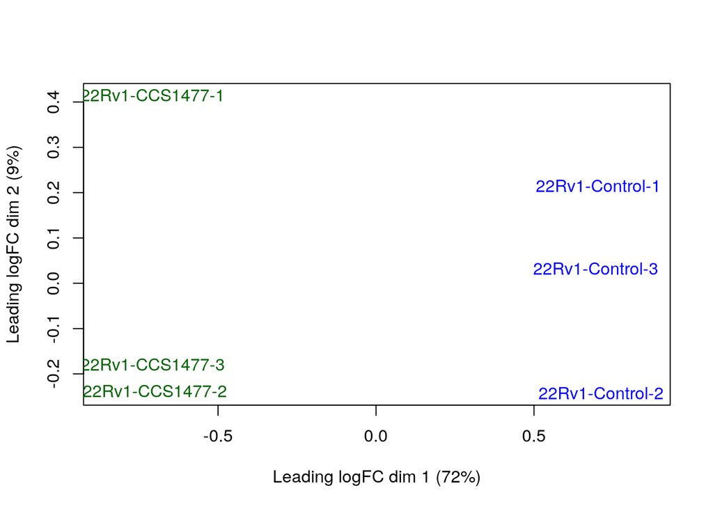

```r
# draw MDS plot
limma::plotMDS(d, labels=rownames(samples),
col = c("darkgreen","blue")[factor(samples$cell_type)])
```

Clear separation between the treatment (CCS1477) and the control is observed.

## Map to HUGO symbols

```r
# ID mapping - from ensembl to HUGO symbol
ensembl <- useMart("ensembl")
ensembl <- useDataset("hsapiens_gene_ensembl",mart=ensembl)

# convert the IDs (first, check if conversion was done previously)
conversion_stash <- "p300_CBP_id_conversion.rds"
if(file.exists(conversion_stash)){
  p300_CBP_id_conversion <- readRDS(conversion_stash)
} else {
  p300_CBP_id_conversion <- getBM(attributes = c("ensembl_gene_id","hgnc_symbol"),
                            filters = c("ensembl_gene_id"),
                            values = p300_CBP_exp_filtered$Geneid,
                            mart = ensembl)
  saveRDS(p300_CBP_id_conversion, conversion_stash)
}

# result: num.genes we were able to map
length(which(rownames(normalized_counts) %in%
                p300_CBP_id_conversion$ensembl_gene_id))
```

```
## [1] 15326
```

```r
# how many did we miss?
nrow(normalized_counts) - length(which(rownames(normalized_counts) %in%
                p300_CBP_id_conversion$ensembl_gene_id))
```

```
## [1] 464
```

```r
# merge the IDs into the same table
p300_CBP_exp_filtered_id_matched <- merge(p300_CBP_id_conversion,normalized_counts,
                                 by.x = 1, by.y = 0, all.y=TRUE)
knitr::kable(p300_CBP_exp_filtered_id_matched[1:10,1:5],type = "html")
```

| ensembl_gene_id | hgnc_symbol | 22Rv1-CCS1477-1 | 22Rv1-CCS1477-2 | 22Rv1-CCS1477-3 |
| --- | --- | --- | --- | --- |
| ENSG00000000003 | TSPAN6 | 19.13208 | 17.92992 | 17.11575 |
| ENSG00000000419 | DPM1 | 55.74524 | 52.13468 | 55.54191 |
| ENSG00000000457 | SCYL3 | 36.56460 | 35.72191 | 39.28757 |
| ENSG00000000460 | C1orf112 | 43.12001 | 39.44582 | 41.01038 |
| ENSG00000001036 | FUCA2 | 63.61173 | 59.41009 | 60.48563 |
| ENSG00000001084 | GCLC | 113.67561 | 103.02806 | 111.79542 |
| ENSG00000001167 | NFYA | 51.22929 | 52.92773 | 51.45960 |
| ENSG00000001460 | STPG1 | 13.45072 | 12.75783 | 11.87241 |
| ENSG00000001461 | NIPAL3 | 94.93200 | 95.37336 | 95.61598 |
| ENSG00000001497 | LAS1L | 51.42353 | 55.89307 | 52.65808 |

```r
# again, how many are missing (using the table)?
ensembl_id_missing_gene <- p300_CBP_exp_filtered_id_matched$ensembl_gene_id[
  which(is.na(p300_CBP_exp_filtered_id_matched$hgnc_symbol))]
length(ensembl_id_missing_gene)
```

```
## [1] 464
```

Since the raw data does not contain the names of genes, it is unknown what these unmapped genes are (Most of them have the same ensembl IDs as in the ca125 example). We will remove these for the sake of making a dataframe with HUGO symbols as rownames[[^6]](http://localhost:8787/files/a1_report.html#fn6).

**For the next assignment:** Create a dataframe with 6 numeric columns & HUGO symbols as rownames of the dataframe

```r
p300_CBP_exp_no_NA <- na.omit(p300_CBP_exp_filtered_id_matched)
dim(p300_CBP_exp_no_NA) # correct!
```

```
## [1] 15326     8
```

```r
p300_CBP_exp_a1 <- p300_CBP_exp_no_NA[3:8]
# But it's still unable to have rownames(p300_CBP_exp_a1) <- p300_CBP_exp_no_NA[,2]

# after removing NA rows, there are still more "duplicated" HUGO symbols...
sum(duplicated(p300_CBP_exp_no_NA[,2]))
```

```
## [1] 864
```

```r
p300_CBP_exp_no_NA$hgnc_symbol[which(duplicated(p300_CBP_exp_no_NA$hgnc_symbol))]
```

[output not shown]

[output cut: 20 more lines]

```r
# they're all empty "". Let's remove them.

remove_row <- which(duplicated(p300_CBP_exp_no_NA$hgnc_symbol))

p300_CBP_exp_no_NA_no_space <- p300_CBP_exp_no_NA[-remove_row, ]
dim(p300_CBP_exp_no_NA_no_space)
```

```
## [1] 14462     8
```

```r
p300_CBP_exp_a1 <- p300_CBP_exp_no_NA_no_space[3:8]
rownames(p300_CBP_exp_a1) <- p300_CBP_exp_no_NA_no_space[,2]
p300_CBP_exp_a1[1:5, 1:5]
```

```
##          22Rv1-CCS1477-1 22Rv1-CCS1477-2 22Rv1-CCS1477-3 22Rv1-Control-1
## TSPAN6          19.13208        17.92992        17.11575        10.90190
## DPM1            55.74524        52.13468        55.54191        61.63943
## SCYL3           36.56460        35.72191        39.28757        39.19164
## C1orf112        43.12001        39.44582        41.01038        34.63768
## FUCA2           63.61173        59.41009        60.48563        68.63137
##          22Rv1-Control-2
## TSPAN6          11.90960
## DPM1            61.81650
## SCYL3           39.56780
## C1orf112        33.28581
## FUCA2           68.53474
```

The final dataset has 14,462 rows. [[^7]](http://localhost:8787/files/a1_report.html#fn7)

# Conclusion & Outlook

From the raw data, low-counts were removed but the outliers were kept. Normalizing the data led to better alignment of distributions. Not all ensembl IDs could be mapped to HUGO symbols, which meant about 10% (1,328 out of 15,790) of rows had to be removed. The dataset is now ready for further analysis in assignement 2.

# Reference

1. Bono JS et al de: **Targeting p300/CBP in lethal prostate cancer.** *Cancer Discov* 2021, **11**:1118–1137.

[^1]: What are the control and test conditions of the dataset?
[^2]: Why is the dataset of interest to you?
[^3]: Were there expression values that were not unique for specific genes? How did you handle these?
[^4]: How many outliers were removed?
[^5]: How did you handle replicates?
[^6]: Were there expression values that could not be mapped to current HUGO symbols?
[^7]: What is the final coverage of your dataset?